# Taxi Availability after New Year Countdown 2020

3 January 2020

### 1. Set Up

```r
library(datagovsgR)
library(dplyr)
library(stringr)
library(lubridate)
library(ggplot2)
library(ggmap)
library(gganimate)
```

```r
hours = c(0:23) %>% as.character() %>% str_pad(width = 2, pad = "0")
minutes = c(00,10,20,30,40,50) %>% as.character() %>% str_pad(width = 2, pad = "0")

output_df_all = data.frame()
```

- Allows for customisation of hours and minute intervals

### 2. Quering of data

```r
for (i in 1:length(hours)) {
  for (j in 1:length(minutes)) {

    input_date_time = paste("2020-01-01T", hours[i], ":", minutes[j], ":", "00", sep = "")
    output_df = taxi_availability(date_time = input_date_time) %>%
      mutate(date_time = paste("2020-01-01",hours[i], minutes[j], sep = ""))

    output_df_all = rbind(output_df_all, output_df)
  }
}

output_df_all$date_time = parse_date_time(output_df_all$date_time, orders = "Ymd HM")
```

- Quering API
- I chose to work in intervals of 10 minutes, on the first day of 2020

#### a. Graph of taxi availability over the 24 hour period

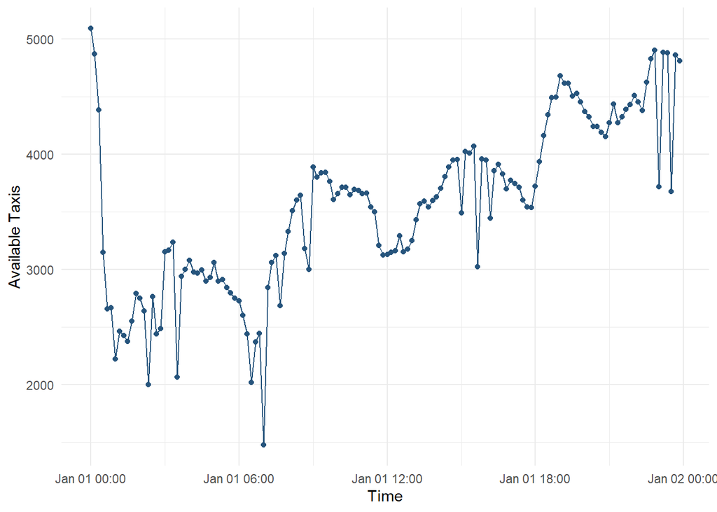

```r
avail_summary = output_df_all %>%
  count(date_time)

ggplot(avail_summary, aes(y = n, x = date_time)) +
  geom_point(col = "#26547c") +
  geom_line(col = "#26547c") +
  labs(y = "Available Taxis", x = "Time") +
  theme_minimal()
```

- There appears to be a huge peak at midnight, and then a sharp drop over the next hour. This might be because of people heading home after the new year countdown.
- Generally, the taxi availability increases over the day, with the lowest around early morning and the rush hour, and the highest at midnight.
- The sharp drop in availability might be due to taxi bookings during the early morning rush hour.

#### b. Average availability by the hour

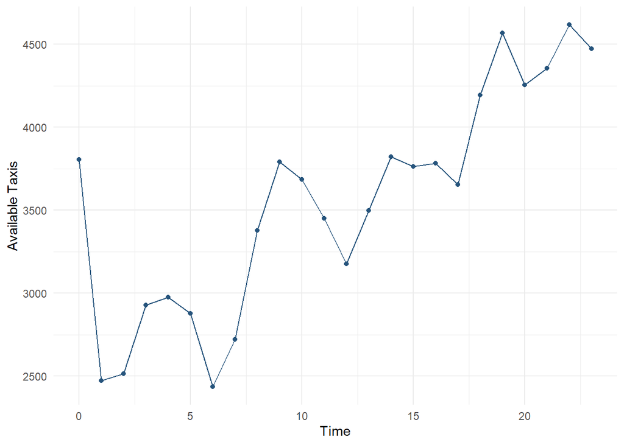

```r
avail_summary %>%
  mutate(hour = hour(date_time)) %>%
  group_by(hour) %>%
  summarise(mean_n = mean(n)) %>%
  ggplot(aes(y = mean_n, x = hour)) +
  geom_point(col = "#26547c") +
  geom_line(col = "#26547c") +
  labs(y = "Available Taxis", x = "Time") +
  theme_minimal()
```

- Graphing by the hour shows a smoother graph, but we lose the peak at midnight noticed earlier.
- General trend remains the same.

### 3. Taxi Locations

```r
register_google(key = Sys.getenv("GOOGLE_MAPS_API_KEY"))
sing <- get_map(location = "singapore",
                zoom = 11,
                maptype = "terrain",
                source = "google")
```

- To obtain the image of Singapore

```r
plot = ggmap(sing) +
  geom_density_2d(aes(y = lat, x = long), data = output_df_all)
```

```r
plot +
  transition_time(date_time) +
  labs(title = 'Date and Time: {frame_time}')
```

[output not shown]

- Doesnt look very nice and looks very complicated
- Maybe it would be smoother if it was by the hour

```r
output_df_all_hoursubset = output_df_all %>%
  filter(minute(date_time) == 0)

p = ggmap(sing) +
  geom_density_2d(aes(y = lat, x = long), data = output_df_all_hoursubset) +
  labs(title = "{closest_state}") +
  transition_states(date_time, transition_length = 0, state_length = 1)

g = output_df_all_hoursubset %>%
  count(date_time) %>%
  ggplot(aes(y = n, x = date_time)) +
  geom_point() +
  geom_line() +
  theme_minimal() +
  transition_reveal(date_time)

# animate(p, fps = 25)
# animate(g, fps = 25)
```

- To my understanding Rmarkdown knitting does not support these animations